# K-Means Clustering

## The strategic team of a mall gathered the following info about the customers of a mall.each row corresponds to a customer visiting the mall. the last variable spending score can range between 1-100 and depicts how much each cust spends at the mall.the lower the score,the lower the customer spends over a period of 1 year.The strategic team wants to understand its customers,and identify a pattern.

## Importing the libraries

```python
# to perform any kind of the operation on the data we need to use the pandas and numpy library
# pandas isimportant to bring the data into the python enviroment
# matplotlib libarray is used to generate the gralhs .
# skitlearn gets the access to all the algorithmns .
# we have imported the warnings so that the code is not filled with the warnings .
# warnings are not the errors.
# when we are creating the highly sophisticated graphs a lot of warnings comes so to
# ignore that we import  the warnings .
# and so we will ignore the warnings .

import numpy as np
import matplotlib.pyplot as plt
import pandas as pd
import sklearn
#print(sklearn.show_versions())
import warnings
warnings.filterwarnings('ignore')
```

```python
# here we have installed the scikit learn pacakge

pip install scikit-learn==1.1.3
```

## To create the matrix of features,we exclude the custid(not needed),though other features are not redundant,we will only keep the annual income and spending score,as that will help us in the visualisation of the clusters in the form of 2 dimentional plots.

```python
# In clustering,we DO NOT HAVE A DEPENDENT VARIABLE.We do the clustering based on the features only.
# a colon : means a range
# here we have created the variable called dataset
# by using the pandas library we are  reading the csv file
# here we have the feature named X
# iloc function is used to fetch  out the last two columns that is 3 , 4 so here we have used
# the index location function iloc.
# when we rae mentioning the iloc function  it is clear that we are going to mention the index
# of the positions of the columns of the index which we want in the ananlysis  .
#  for slicing we will always use the box bracket .
# colon is used because  when we are using the slicing method  then the 1st component refers to
# the rows and the 2nd component refers to the columns
#  so in the case of the rows we are writing colon that means select all  the rows and then giving
# a comma and writing 3 , 4 that means the index 2nd last column and the last column
# .values      - it is used to convert the values into the arrays .

dataset = pd.read_csv('Kmeans_Customers.csv')
X = dataset.iloc[:, [3,4]].values
```

```python
# here we are checking for the feature set
# here we have only 2  values of the data
# 2 values are the -  one is the spending score and one is the income

X
```

```
array([[ 15,  39],
       [ 15,  81],
       [ 16,   6],
       [ 16,  77],
       [ 17,  40],
       [ 17,  76],
       [ 18,   6],
       [ 18,  94],
       [ 19,   3],
       [ 19,  72],
       [ 19,  14],
       [ 19,  99],
       [ 20,  15],
       [ 20,  77],
       [ 20,  13],
       [ 20,  79],
       [ 21,  35],
       [ 21,  66],
       [ 23,  29],
       [ 23,  98],
       [ 24,  35],
       [ 24,  73],
       [ 25,   5],
       [ 25,  73],
       [ 28,  14],
       [ 28,  82],
       [ 28,  32],
       [ 28,  61],
       [ 29,  31],
       [ 29,  87],
       [ 30,   4],
       [ 30,  73],
       [ 33,   4],
       [ 33,  92],
       [ 33,  14],
       [ 33,  81],
       [ 34,  17],
       [ 34,  73],
       [ 37,  26],
       [ 37,  75],
```

[output cut: 145 more lines]

```
       [ 99,  97],
       [101,  24],
       [101,  68],
       [103,  17],
       [103,  85],
       [103,  23],
       [103,  69],
       [113,   8],
       [113,  91],
       [120,  16],
       [120,  79],
       [126,  28],
       [126,  74],
       [137,  18],
       [137,  83]], dtype=int64)
```

## We will not have a split of training and test set as we do not have a dependent variable.

## Using the elbow method to find the optimal number of clusters

## As kmeans is an iterative process,whereby at each step we compute the seed points,we use a loop to run our code iteratively

## Traditional k-means utilizes a randomization process for initializing these centroids -- though this is not the only approach -- but poor initialization can lead to increased numbers of required clustering iterations to reach convergence, and a less-efficient algorithm overall. k-means++ is relatively consistent within clusters, with the specific data points selected as initial centroids varying slightly.

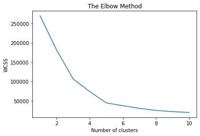

```python
# We create 10 clusters initailly
# here we are importing the kmeans module from the sklearn.cluster pacakge
# ideally the value of k means intial point should be odd.

from sklearn.cluster import KMeans

# wcss is initialised as an empty list , which will be populated with the wcss of
# each cluster as the loop iterates
# here we have  created the global valiable which is wcss  , which is the empty list
# once the wcss will be populated with the value  then it  the list will be filled up with values
# then the list fills up .

wcss = []

# for 10 clusters,the upper bound is 11,as the range will include 1 less than the upper bound limit
# here ideally we will get the 10 clusters

for i in range(1, 11):

# hre k means is the object
# the object is created from the class and the class name is k means
# we works with the object not with the class
# here we are not applying the traditional k means clustering but here we are applying the
# k means ++ clustering  which will be giving the optimal numbers of the clusters .
# random state ensures the permanently .
# random state value depends on the choice
# if we will execute the code 100 times , 100 times the resulrt will be same
# n_clusters = i - it means number of clusters = i that means i = 10  that means the initial
# number of clusters is 10
# if the optimal number of clusters and the initial number of clusters  are close to each other
# then it is fine or if  not go with the other numbers of clusters
# the value should be very close to the optimal number of clusters .

    kmeans = KMeans(n_clusters = i, init = 'k-means++', random_state = 42)

# Fit method helps to run the loop/algorithmn on the training set
# here we are fitting the x feature to the  k means

    kmeans.fit(X)

# inertia is the parameter of the object kmeans which helps us generate wcss
# here we have created the object called wcss  and we have created it as the empty list
# we have appended the kmeans as an inertia .
# this inertia will create the wcss
# then the wcss is generated

    wcss.append(kmeans.inertia_)

# we start this line shifting indent to left,to confirm that we are out of loop
# here we are plotting the plot  having the x and y axis
# we are having the range of 1 to 11 on the x axis and  having the wcss on the y axis .

    plt.plot(range(1, 11), wcss)

# range 1-11 shows what reflects in X axis,while wcss reflects in y axis
# here we are plotting the title of the graph

    plt.title('The Elbow Method')

# then we are giving the label of the x label and the y label

    plt.xlabel('Number of clusters')

    plt.ylabel('WCSS')

# then we are plotting to show the graph

    plt.show()

# observations

# when we are plotting the wcss we always go with the last bend in the graph  then atlast it
# will be nearer to the constant
#THE OPTIMAL NUMBER OF CLUSTERS IS 5
```

## Method for initialization: 'k-means++' : selects initial cluster centers for k-mean clustering in a smart way to speed up convergence.

## Fitting the K-Means model on the dataset

```python
# here we have created the variable / objecct called k means
#  then we are having the n number of clusters = 5
# then we have used the initial method of k means ++
# then we have used the random state

kmeans = KMeans(n_clusters = 5, init = 'k-means++', random_state = 42)

# this line trains the kmeans model to identify 5 clusters,and creates a DV with
# these 5 clstrs,DV will be 0,1,2,3,4(5 clusters)

# then we will predict the segeration of the customers in the clusters
# with the help of the predict we will see that which customer falls in which cluster
# so here we have created the variable/object called y_kmeans
# then we are predicting the X feature through fit function through k means

y_kmeans = kmeans.fit_predict(X)
```

```python
# then here we are printing the  y_kmeans to get the predictions

print(y_kmeans)

# observations
# how to intrepet this output -
# the python counting starts from 0
# the 1st customer that is 2 belongs to the 3rd cluster
# similary the 2nd customer that is 3 belongs to the 4th cluster
# so from the observations we can say that there are total 5 clusters
```

```
[2 3 2 3 2 3 2 3 2 3 2 3 2 3 2 3 2 3 2 3 2 3 2 3 2 3 2 3 2 3 2 3 2 3 2 3 2
 3 2 3 2 3 2 0 2 3 0 0 0 0 0 0 0 0 0 0 0 0 0 0 0 0 0 0 0 0 0 0 0 0 0 0 0 0
 0 0 0 0 0 0 0 0 0 0 0 0 0 0 0 0 0 0 0 0 0 0 0 0 0 0 0 0 0 0 0 0 0 0 0 0 0
 0 0 0 0 0 0 0 0 0 0 0 0 4 1 4 0 4 1 4 1 4 0 4 1 4 1 4 1 4 1 4 0 4 1 4 1 4
 1 4 1 4 1 4 1 4 1 4 1 4 1 4 1 4 1 4 1 4 1 4 1 4 1 4 1 4 1 4 1 4 1 4 1 4 1
 4 1 4 1 4 1 4 1 4 1 4 1 4 1 4]
```

### plt.scatter(X[y_kmeans == 0,0]) #when creating a scatterplot,we have to have the X cordinate as the first arg as it contains the number of features. [,0] implies we want to select those customers who fall in the first cluster.[y_kmeans == 0,0] implies we want to select only those rows of customers from the y_kmeans object who fall in the first cluster.Now X has 2 columns,1st column is the income,and 2nd column is the spending score.as the X cordinate takes all the rowsof data which fall in cluster 1 and the 1st column(0),the Y cordinate will also take all the rows for the first cluster,but the 2nd column(1).So,x-coord=(X[y_kmeans ==0,0])y-coord=(X[y_kmeans== 0,1]) for our first cluster.

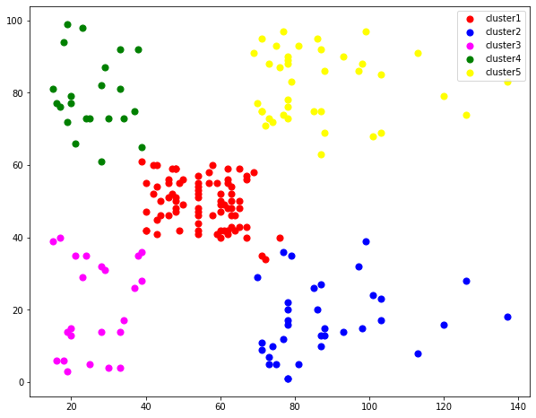

```python
# here  we are plotting the figure having the figure size of 10, 8 that the height and
# width of the graph

plt.figure(figsize=(10,8))

# here we are plotting the scatter plot
# here  we are plotting the clusters
# here we are plotting the 2 values that are income and the spending scores
# from the X feature set from the y_kmeans take the 1st cluster that is the income and this
# will be on the x axis then from the 2nd cluster chhose the 2nd variable that is the spending
# scores which will be on the y axis for all the customers present in the cluster 1
#  so in cluster 1 we have plotted  the income and the spending scores of the customers present
# in the cluster 1
# the 1st component give the cluster number that is the cluster 1 and the 2nd component gives the
# row and column name
# 0,0 - here the 0 means the 1st cluster and the 2nd 0 means the variable on the x axix that is
# the income
# 0,1 - here the 0 means the 1st cluster and the 2nd  1 means the variable on the y axis  that
# is the spending scores
# then we have given the cluster point is having the size of 50
# then we have created the legend
# we are creating the label so that we can create a legend
# without creating alabel we cannot create a legend
# legend is at the top right hand corner to get the summary of the  graphical result .
# we are plotting the income on the x axis along with the spending scores on the y axis
# for each of the clusters
# then we are plotting the legend
# then we are plotting to show the graph

plt.scatter(X[y_kmeans==0,0],X[y_kmeans==0,1],s=50,c='r',label='cluster1')
plt.scatter(X[y_kmeans==1,0],X[y_kmeans==1,1],s=50,c='blue',label='cluster2')
plt.scatter(X[y_kmeans==2,0],X[y_kmeans==2,1],s=50,c='magenta',label='cluster3')
plt.scatter(X[y_kmeans==3,0],X[y_kmeans==3,1],s=50,c='green',label='cluster4')
plt.scatter(X[y_kmeans==4,0],X[y_kmeans==4,1],s=50,c='yellow',label='cluster5')
plt.legend()
plt.show()
```

## Insights---:

```python
# Cluster 5---earns high,spends high-----good customers
# cluster 4---earn less,spends more -----Volatile customer segment,high risk takers
# cluster 3 ---earn less,spend less ------okay customers(not high spenders)
# cluster 2 -----earn more,spends less------target group(risk aversers)
# cluster 1-----earns moderate,spends moderate----okay customers
```